# Location sorting and endogenous amenities: Evidence from Amsterdam

Almagro and Dominguez-lino (**Conditionally accepted at Econometrica**)

Hyoungchul Kim

Wharton UPenn

February 4, 2025

## Motivation

#### Amenity, sorting, inquality

- Socioeconomic inequality is tightly linked to residential choice.
- Important mechanism that amplifies this inequality: Endogenous amenity.

#### Amenity is endogenous

- (Local) Amenity is not a fixed value but an equilibrium outcome.
  - Households make location choices based on their heterogeneous preferences on different dimension of amenities.
  - Local amenities cater to the need of the demographic composition in their neighborhoods.

Thus, fully characterizing this nature of *endogenous amenity* is important in understanding its effect on welfare inquality.

## Challenges in prior literature

#### Crude understanding of the nature of amenity

- Amenities are typically modeled as a one-dimensional object (aggregating the variety of location characteristics).

#### Aggregation of amenity into single-index does not allow…

- Households’ diverse tastes for different consumption amenities **(horizontal differentiation of neighborhood on the demand side)**.
- Fims providing such amenities cater to this heterogeneity **(differential supply-side responses to consumer heterogeneity)**.
- A more full picture to help design policies that alleviate urban inequality.

Possibly due to lack of data, model, shock, etc.

## Research question

#### How does preference heterogeneity over multiple endogenous consumption amenities shape with-city residential sorting and inequality?

- How does significant change in local residential composition (e.g. tourism in Amsterdam) affect local residential markets (rental price) and amenity markets (change in local amenities for residents and tourists).

## Methodology

#### “Reduced-form” regression to show stylized facts and motivation

- Shift-share IV regression to causally estimate the impact of mass tourism on local housing and amenity markets.
- Identification: “Shift” *(time variation in worldwide demand for STR)* - “Share” *(neighborhood-level exposure to tourism using spatial distribution of historic monuments)*
  - Higher STR entry led to higher rental price.
  - Amenities have tilted toward tourists and away from locals.
  - The composition of residents has changed heterogeneously across neighborhoods.

#### “Structural model”

- Build a dynamic model of a city’s rental market that consists of:
  1. Heterogeneous households and tourist making location decisions,
  2. Landlords who can rent their units to local or tourists,
  3. A market for amenities that microfounds how the composition of amenities endogenously responds to the composition of locals and tourists.

## Data overview

#### Individual-level data: Statistical bureau of the Netherlands’ Centraal Bureau voor de Statistiek (CBS)

- Construct a panel of residential history for the universe of individuals $+$ household-level demographics from tax return data (income, education, employment status, etc).

#### Housing unit data: CBS tax appraisal panel and national rent survey

- Universe of residential housing units (property value, occupant’s tenancy status, rental prices, etc).

#### Short-term rental (STR) listings: Airbnb listing-level observations (geo-coordinates, prices, etc)

*Final sample: Annual panel of location choices and characteristics for 2008-2018 in 22 districts.*

## Related literature

#### Spatial equilibrium model: Benchmark to study spatial inequality across and within cities

- Focus on within-city margin but silent on the mechanisms through which specific amenities are provided: Bayer et al. (2007); Guerrieri et al. (2013); Ahlfeldt et al. (2015); Su (2022).
- Impose structure on amenity but lack heterogeneity in residents’ preferences over amenities or collapse amenities into a single quality index: Couture et al. (2021); hoelzlein (2020); Miyauchi et al. (2021).
  - This paper contributes by allowing for preference heterogeneity over multiple and differentiated amenities.

#### STR industry: Simultaneously studying effects of tourism on both residential and amenity markets

- Calder-Wang (2021): Distributional effects of STR industry on NYC rental market.
- Allen et al. (2021): The effects of seasonal tourism on prices of goods and amenities borne by residents of Barcelona.

#### Discrete-choice tools: Euler Equation in Conditional Choice Probabilities estimator for dynamic estimation

- Hotz and Miller (1993); Arcidiacono and Miller (2011); Aguirregabiria and Magesan (2013); Scott (2013); Kalouptsidi et al. (2021b); Hsiao (2021); Traiberman (2019); Humlum (2021); Diamond, McQuade and Qian (2019); Davis et al. (2019); Davis et al. (2021).

## Descriptive evidence

- Fact 1: Tourists and STR listings have grown dramatically and sprawled across Amsterdam.
- Fact 2: Rents have increased more in neighborhoods with more STR entry.
- Fact 3: Amenities have tilted towards tourists and away from locals.
- Fact 4: The composition of residents has changed heterogeneously across neighborhoods.

#### Airbnb intensity and housing market outcomes

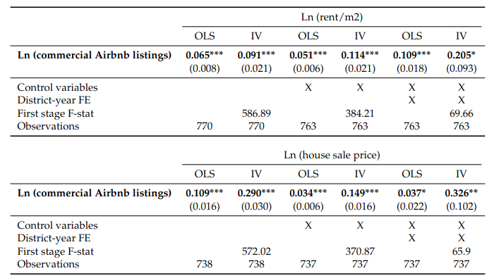

#### Spatial correlation between tourist-oriented and local-oriented amenities

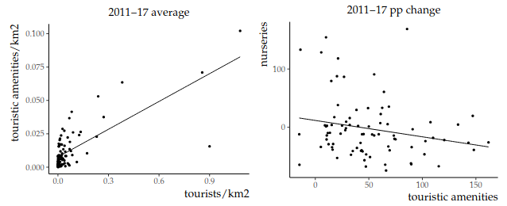

## Economic model 1: Endogenous amenities

**Notation**: $J+1$ locations; $K$ types of locals and tourist type $T$; $S$ sectors; Population composition $M_{jt} \equiv [M_{jt}^1, ... , M_{jt}^K, M_{jt}^T]'$; Amenities $a_{jt} \equiv [N_{1jt}, ..., N_{sjt}]'$

#### Demand for amenities

Household with Cobb-Douglass (CD) perferences over housing $H$ and amenities $C$, CD preferences across amenity sector and CES preferences over varieties within a sector:

$$q_{isjt} = \sum_k q_{isjt}^k M_{jt}^k, \quad \text{where} \, \, q_{isjt}^k = \frac{\alpha_s^k \phi^k \omega_t^k}{p_{isjt}}\left( \frac{p_{isjt}}{P_{sjt}}\right)^{1-\sigma_s}$$

#### Supply of amenities (monopolistic competition, same marginal cost, free entry): Zero-profit condition

$$(p_{sjt} - c_{sjt}) q_{sjt} = \underbrace{F_{sjt}(N_{jt})}_{\text{Fixed cost per period}}, \quad \text{where} \, \, N_{jt} = \sum_s N_{sjt}.$$

#### Equilibrium amenities: Adding up equations above gives market clearing condition

$$N_{sjt} = \frac{1}{\sigma_s F_{sjt}} \sum_k \alpha_s^k \phi^k \omega_t^k M_{jt}^k, \quad a_{jt}=A(M_{jt})$$

## Economic model 2: Housing supply

- Total housing stock (measured in units of floor space) $H_{jt}$ is assumed to be inelastic in the short-rn and follows an exogenously determined path over time.
- A continuum of absentee landlords make a binary choice between renting in the long-term market (LT) or in the short-term market (ST).

#### An individual landlord’s problem

$$\max\{ \alpha \cdot \overbrace{\gamma_{jt}}^{\text{LT income}} + \varepsilon_{LT}, \, \, \alpha \cdot \underbrace{p_{jt}}_{\text{ST income}} - \overbrace{\kappa_{jt}}^{\text{operating cost}} + \varepsilon_{ST} \},$$

#### Housing supply in each location

$$H_{jt}^{LT,S} (\gamma_{jt}, p_{jt}) = \frac{\exp(\alpha \gamma_{jt})}{\exp (\alpha \gamma_{jt}) + \exp(\alpha p_{jt} - \kappa_{jt})} H_{jt},$$

$$H_{jt}^{ST,S} (\gamma_{jt}, p_{jt}) = H_{jt} - H_{jt}^{LT,S} (\gamma_{jt}, p_{jt}).$$

## Economic model 3: Housing demand

#### Housing demand for locals

$$H_{jt}^{LT,D} (\gamma_t, a_t) = \sum_{k=1}^K M_{jt}^k (r_t, a_t) f_{jt}^k.$$

#### Housing demand for tourists

$\exists$ an exogenous number of tourists $M_t^T$ arriving into the city and choosing to stay in a short-term rental or a hotel. Housing demand from tourists in each location becomes:

$$H_{jt}^{ST,D} (p_{jt}, a_t) = \overbrace{M_{jt}^{ST} (p_t, a_t)}^{\text{tourists staying in ST}} \cdot \underbrace{f_{jt}}_{\text{average size of a unit in location j}}$$

## Economic model 4: Equilibrium

Population composition, rents, STR prices, and amenities are endogenously and jointly determined in stationary equilibrium.

**Definition (Stationary equilibrium) - Brief version**

In *stationary equilibrium*,

1. the long-term rental market clears for every location,
2. the short-term rental market clears for every location,
3. the amenities market clears.

## Robustness checks

#### Robustness of real estate supply elasticity

- The paper’s main counterfactuals are robust to different supply elasticities, ranging from the baseline inelastic San Francisco case to the highly elastic case of Atlanta.

#### Comparison of static and dynamic model estimates

- Examine the impact of removing forward-looking behavior ($\beta = 0$) and location capital, i.e., the dynamic state-dependent component of moving costs.
- Most of the coefficients of the demand estimates become significantly different, hinting the importance of dynamic component in the model.

## Conclusion

- This paper studies the role of preference heterogeneity over a set of endogenous location amenities in shaping within-city sorting and welfare inequality.
  - Build a model of residential choice where heterogeneous, forward-looking households consume a bundle of amenities provided by firms in a market for non-tradables.
  - Unlike past literature, the paper microfounds how different consumption amenities arise in equilibrium, endogenizing the extent to which neighborhoods become horizontally differentiated.

#### Empirical findings

- Heterogeneity in the preferences of residents and supply responses of firms are substantial.
- Distributional incidence of urban policies depends on heterogeneity on both demand and supply side of the amenities market.